# Classify different data sets

### Basic includes

```python
# Using pandas to load the csv file
import pandas as pd

import numpy as np
import matplotlib.pyplot as plt

from keras import models
from keras import layers
from keras import callbacks
from keras.utils import to_categorical

# reuters and fashin mnist data set from keras
from keras.datasets import reuters
from keras.datasets import fashion_mnist

# needed to preprocess text
from keras.preprocessing.text import Tokenizer
```

### Classify the Fashion Mnist

```
(60000, 28, 28)
(10000, 28, 28)
```

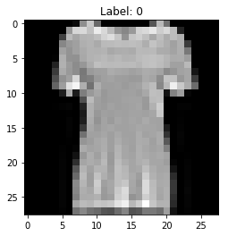

```python
(fashion_train_data, fashion_train_labels), (fashion_test_data, fashion_test_labels) = fashion_mnist.load_data()

print(fashion_train_data.shape)
print(fashion_test_data.shape)

test_index = 10

plt.title("Label: " + str(fashion_train_labels[test_index]))
plt.imshow(fashion_train_data[test_index], cmap="gray")
```

#### TO DO: Preprocess the data

1. Normalize the input data set
2. Perform one hot encoding
3. Create a train, test, and validation set

```python
# Flatten the arrays
fashion_train_data = fashion_train_data.reshape((60000, 28 * 28))
fashion_test_data = fashion_test_data.reshape((10000, 28 * 28))

# Turn values from 0-255 to 0-1
fashion_train_data = fashion_train_data.astype('float32') / 255
fashion_test_data = fashion_test_data.astype('float32') / 255

# One Hot Encoding
fashion_train_labels = to_categorical(fashion_train_labels)
fashion_test_labels = to_categorical(fashion_test_labels)
```

1. Use a validation set
2. Propose and train a network
3. Print the history of the training
4. Evaluate with a test set

```python
# Proposing Network Model
network = models.Sequential()

# Dense layers: fully connected layers
network.add(layers.Dense(400, activation='relu', input_shape=(28 * 28,)))
network.add(layers.Dropout(0.1))
network.add(layers.Dense(100, activation='relu'))
network.add(layers.Dropout(0.1))
network.add(layers.Dense(60, activation='relu'))
network.add(layers.Dropout(0.1))
network.add(layers.Dense(50, activation='relu'))
network.add(layers.Dropout(0.1))
network.add(layers.Dense(20, activation='relu'))
network.add(layers.Dropout(0.1))
network.add(layers.Dense(10, activation='softmax'))

# included the early stopping which monitors the validation loss
early_stop = callbacks.EarlyStopping(monitor='val_loss', patience=10)

network.compile(optimizer='adam', loss='categorical_crossentropy', metrics=['accuracy'])

network.summary()
```

```
_________________________________________________________________
Layer (type)                 Output Shape              Param #
=================================================================
dense_1 (Dense)              (None, 400)               314000
_________________________________________________________________
dropout_1 (Dropout)          (None, 400)               0
_________________________________________________________________
dense_2 (Dense)              (None, 100)               40100
_________________________________________________________________
dropout_2 (Dropout)          (None, 100)               0
_________________________________________________________________
dense_3 (Dense)              (None, 60)                6060
_________________________________________________________________
dropout_3 (Dropout)          (None, 60)                0
_________________________________________________________________
dense_4 (Dense)              (None, 50)                3050
_________________________________________________________________
dropout_4 (Dropout)          (None, 50)                0
_________________________________________________________________
dense_5 (Dense)              (None, 20)                1020
_________________________________________________________________
dropout_5 (Dropout)          (None, 20)                0
_________________________________________________________________
dense_6 (Dense)              (None, 10)                210
=================================================================
Total params: 364,440
Trainable params: 364,440
Non-trainable params: 0
_________________________________________________________________
```

```python
# Train the model

# network.fit(fashion_train_data, fashion_train_labels, epochs=100)

# You can manually create and add the validation set, or...

# history = network.fit(fashion_train_data, fashion_train_labels,
#           batch_size=512,
#           epochs=40,
#           validation_data=(validation_data, validation_labels),
#           verbose=2)

# You can let keras make it for you by telling it which percetage of the train data
# will be used as validation. In this case through the validation_split argument.
# Here, it is taking 20% of the train data to use for validation.
history = network.fit(fashion_train_data, fashion_train_labels,
          batch_size=512,
          epochs=200,
          validation_split=0.2,
          callbacks=[early_stop],
          verbose=2)

test_loss, test_acc = network.evaluate(fashion_test_data, fashion_test_labels)
print("test loss: ", test_loss, "test accuracy: ", test_acc)
```

```
Train on 48000 samples, validate on 12000 samples
 - 7s - loss: 1.1569 - acc: 0.6143 - val_loss: 0.5595 - val_acc: 0.8101
 - 5s - loss: 0.6113 - acc: 0.7984 - val_loss: 0.4373 - val_acc: 0.8487
 - 5s - loss: 0.5001 - acc: 0.8320 - val_loss: 0.4025 - val_acc: 0.8562
 - 5s - loss: 0.4423 - acc: 0.8514 - val_loss: 0.3791 - val_acc: 0.8649
 - 5s - loss: 0.4062 - acc: 0.8618 - val_loss: 0.3832 - val_acc: 0.8647
 - 6s - loss: 0.3848 - acc: 0.8661 - val_loss: 0.3575 - val_acc: 0.8729
 - 5s - loss: 0.3660 - acc: 0.8743 - val_loss: 0.3567 - val_acc: 0.8710
 - 6s - loss: 0.3441 - acc: 0.8795 - val_loss: 0.3383 - val_acc: 0.8785
 - 6s - loss: 0.3351 - acc: 0.8824 - val_loss: 0.3337 - val_acc: 0.8793
 - 6s - loss: 0.3251 - acc: 0.8867 - val_loss: 0.3353 - val_acc: 0.8827
 - 5s - loss: 0.3101 - acc: 0.8904 - val_loss: 0.3366 - val_acc: 0.8848
 - 5s - loss: 0.3016 - acc: 0.8940 - val_loss: 0.3281 - val_acc: 0.8857
 - 5s - loss: 0.2939 - acc: 0.8970 - val_loss: 0.3315 - val_acc: 0.8822
 - 5s - loss: 0.2940 - acc: 0.8967 - val_loss: 0.3324 - val_acc: 0.8844
 - 5s - loss: 0.2788 - acc: 0.9006 - val_loss: 0.3163 - val_acc: 0.8913
 - 5s - loss: 0.2704 - acc: 0.9048 - val_loss: 0.3214 - val_acc: 0.8858
 - 5s - loss: 0.2659 - acc: 0.9057 - val_loss: 0.3334 - val_acc: 0.8847
 - 5s - loss: 0.2621 - acc: 0.9080 - val_loss: 0.3215 - val_acc: 0.8902
 - 5s - loss: 0.2581 - acc: 0.9074 - val_loss: 0.3377 - val_acc: 0.8859
 - 5s - loss: 0.2486 - acc: 0.9126 - val_loss: 0.3191 - val_acc: 0.8892
 - 5s - loss: 0.2478 - acc: 0.9107 - val_loss: 0.3317 - val_acc: 0.8906
 - 5s - loss: 0.2436 - acc: 0.9147 - val_loss: 0.3186 - val_acc: 0.8923
 - 5s - loss: 0.2361 - acc: 0.9146 - val_loss: 0.3130 - val_acc: 0.8925
 - 5s - loss: 0.2278 - acc: 0.9176 - val_loss: 0.3214 - val_acc: 0.8943
 - 5s - loss: 0.2257 - acc: 0.9184 - val_loss: 0.3286 - val_acc: 0.8945
 - 5s - loss: 0.2248 - acc: 0.9187 - val_loss: 0.3132 - val_acc: 0.8940
 - 5s - loss: 0.2230 - acc: 0.9195 - val_loss: 0.3155 - val_acc: 0.8947
 - 5s - loss: 0.2151 - acc: 0.9229 - val_loss: 0.3234 - val_acc: 0.8956
 - 6s - loss: 0.2105 - acc: 0.9240 - val_loss: 0.3336 - val_acc: 0.8938
 - 6s - loss: 0.2077 - acc: 0.9257 - val_loss: 0.3339 - val_acc: 0.8958
 - 5s - loss: 0.2054 - acc: 0.9266 - val_loss: 0.3259 - val_acc: 0.8937
 - 5s - loss: 0.1954 - acc: 0.9284 - val_loss: 0.3392 - val_acc: 0.8958
 - 5s - loss: 0.1996 - acc: 0.9292 - val_loss: 0.3404 - val_acc: 0.8962
test loss:  0.3699287251353264 test accuracy:  0.892
```

```python
# This dictionary stores the validation and accuracy of the model throughout the epochs
history_dict = history.history
print(history_dict.keys())
```

```
dict_keys(['val_loss', 'val_acc', 'loss', 'acc'])
```

```python
# # The history values are split in different lists for ease of plotting
acc = history_dict['acc']
val_acc = history_dict['val_acc']
loss = history_dict['loss']
val_loss = history_dict['val_loss']
epochs = range(1, len(acc) + 1)
```

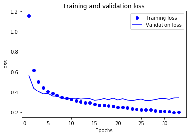

```python
# Plot of the validation and training loss

# "bo" is for "blue dot"
plt.plot(epochs, loss, 'bo', label='Training loss')
# b is for "solid blue line"
plt.plot(epochs, val_loss, 'b', label='Validation loss')
plt.title('Training and validation loss')
plt.xlabel('Epochs')
plt.ylabel('Loss')
plt.legend()

plt.show()
```

## Classifying newswires

Build a network to classify Reuters newswires into 46 different mutually-exclusive topics.

### Load and review the data

```python
(reuters_train_data, reuters_train_labels),(reuters_test_data, reuters_test_labels) = reuters.load_data(num_words=10000)

print(reuters_train_data.shape)
print(reuters_train_labels.shape)
print(reuters_train_data[0])
print(reuters_train_labels[0])

print(set(reuters_train_labels))
```

```
(8982,)
(8982,)
[1, 2, 2, 8, 43, 10, 447, 5, 25, 207, 270, 5, 3095, 111, 16, 369, 186, 90, 67, 7, 89, 5, 19, 102, 6, 19, 124, 15, 90, 67, 84, 22, 482, 26, 7, 48, 4, 49, 8, 864, 39, 209, 154, 6, 151, 6, 83, 11, 15, 22, 155, 11, 15, 7, 48, 9, 4579, 1005, 504, 6, 258, 6, 272, 11, 15, 22, 134, 44, 11, 15, 16, 8, 197, 1…
3
{0, 1, 2, 3, 4, 5, 6, 7, 8, 9, 10, 11, 12, 13, 14, 15, 16, 17, 18, 19, 20, 21, 22, 23, 24, 25, 26, 27, 28, 29, 30, 31, 32, 33, 34, 35, 36, 37, 38, 39, 40, 41, 42, 43, 44, 45}
```

Load the word index to decode the train data.

```python
word_index = reuters.get_word_index()

reverse_index = dict([(value+3, key) for (key, value) in word_index.items()])

reverse_index[0] = "<PAD>"
reverse_index[1] = "<START>"
reverse_index[2] = "<UNKNOWN>"  # unknown
reverse_index[3] = "<UNUSED>"

decoded_review = ' '.join([reverse_index.get(i,'?') for i in reuters_train_data[0]])

print(decoded_review)
```

```
<START> <UNKNOWN> <UNKNOWN> said as a result of its december acquisition of space co it expects earnings per share in 1987 of 1 15 to 1 30 dlrs per share up from 70 cts in 1986 the company said pretax net should rise to nine to 10 mln dlrs from six mln dlrs in 1986 and rental operation revenues to 1…
```

#### TO DO: Preprocess the data

1. Normalize the input data set
2. Perform one hot encoding
3. Create a train, test, and validation set

```python
num_words=10000
# Normalize the input data set
tokenizer = Tokenizer(num_words=num_words)
reuters_train_data = tokenizer.sequences_to_matrix(reuters_train_data, mode='binary')
reuters_test_data = tokenizer.sequences_to_matrix(reuters_test_data, mode='binary')
print(reuters_train_data.shape)
print(reuters_test_data.shape)
```

```
(8982, 10000)
(2246, 10000)
```

```python
# Perform One hot encoding
reuters_test_labels = to_categorical(reuters_test_labels)
reuters_train_labels = to_categorical(reuters_train_labels)
```

1. Use a validation set
2. Propose and train a network
3. Print the history of the training
4. Evaluate with a test set

```python
# Propose and train a network
num_classes = 46

# Building the model architecture
model = models.Sequential()
model.add(layers.Dense(500, activation='relu', input_dim=num_words))
model.add(layers.Dropout(0.1))
model.add(layers.Dense(300, activation='relu'))
model.add(layers.Dropout(0.1))
model.add(layers.Dense(100, activation='relu'))
model.add(layers.Dropout(0.1))
model.add(layers.Dense(50, activation='relu'))
model.add(layers.Dropout(0.1))
model.add(layers.Dense(num_classes, activation='softmax'))
model.summary()

# included the early stopping which monitors the validation loss
# early_stop = callbacks.EarlyStopping(monitor='val_loss', patience=5)
model.compile(loss='categorical_crossentropy',
              optimizer='adam',
              metrics=['categorical_accuracy'])

# Early Stop
early_stop = callbacks.EarlyStopping(monitor='val_loss', patience=10)

print(reuters_train_data.shape," ", reuters_train_labels.shape)
```

```
_________________________________________________________________
Layer (type)                 Output Shape              Param #
=================================================================
dense_7 (Dense)              (None, 500)               5000500
_________________________________________________________________
dropout_6 (Dropout)          (None, 500)               0
_________________________________________________________________
dense_8 (Dense)              (None, 300)               150300
_________________________________________________________________
dropout_7 (Dropout)          (None, 300)               0
_________________________________________________________________
dense_9 (Dense)              (None, 100)               30100
_________________________________________________________________
dropout_8 (Dropout)          (None, 100)               0
_________________________________________________________________
dense_10 (Dense)             (None, 50)                5050
_________________________________________________________________
dropout_9 (Dropout)          (None, 50)                0
_________________________________________________________________
dense_11 (Dense)             (None, 46)                2346
=================================================================
Total params: 5,188,296
Trainable params: 5,188,296
Non-trainable params: 0
_________________________________________________________________
(8982, 10000)   (8982, 46)
```

```python
history = model.fit(reuters_train_data, reuters_train_labels,
          batch_size=512,
          epochs=200,
          validation_split=0.2,
          callbacks=[early_stop],
          verbose=2)
```

```
Train on 7185 samples, validate on 1797 samples
 - 10s - loss: 2.9629 - categorical_accuracy: 0.4118 - val_loss: 1.8733 - val_categorical_accuracy: 0.5726
 - 8s - loss: 1.6704 - categorical_accuracy: 0.6185 - val_loss: 1.5098 - val_categorical_accuracy: 0.6795
 - 8s - loss: 1.2745 - categorical_accuracy: 0.6997 - val_loss: 1.2790 - val_categorical_accuracy: 0.7168
 - 8s - loss: 0.9801 - categorical_accuracy: 0.7652 - val_loss: 1.1859 - val_categorical_accuracy: 0.7262
 - 8s - loss: 0.7520 - categorical_accuracy: 0.8113 - val_loss: 1.1532 - val_categorical_accuracy: 0.7546
 - 8s - loss: 0.5697 - categorical_accuracy: 0.8539 - val_loss: 1.1784 - val_categorical_accuracy: 0.7691
 - 8s - loss: 0.4237 - categorical_accuracy: 0.8910 - val_loss: 1.1688 - val_categorical_accuracy: 0.7724
 - 8s - loss: 0.3449 - categorical_accuracy: 0.9122 - val_loss: 1.2221 - val_categorical_accuracy: 0.7813
 - 8s - loss: 0.2640 - categorical_accuracy: 0.9294 - val_loss: 1.2966 - val_categorical_accuracy: 0.7863
 - 8s - loss: 0.2180 - categorical_accuracy: 0.9424 - val_loss: 1.3214 - val_categorical_accuracy: 0.7896
 - 8s - loss: 0.1993 - categorical_accuracy: 0.9495 - val_loss: 1.3375 - val_categorical_accuracy: 0.7902
 - 8s - loss: 0.1719 - categorical_accuracy: 0.9556 - val_loss: 1.3628 - val_categorical_accuracy: 0.7852
 - 8s - loss: 0.1603 - categorical_accuracy: 0.9599 - val_loss: 1.4422 - val_categorical_accuracy: 0.7780
 - 8s - loss: 0.1518 - categorical_accuracy: 0.9616 - val_loss: 1.3859 - val_categorical_accuracy: 0.7852
 - 8s - loss: 0.1382 - categorical_accuracy: 0.9627 - val_loss: 1.3832 - val_categorical_accuracy: 0.7819
```

```python
test_loss, test_acc = model.evaluate(reuters_test_data, reuters_test_labels)
print("test loss: ", test_loss, "test accuracy: ", test_acc)
```

```
test loss:  1.432131525245184 test accuracy:  0.7862867320210193
```

```python
# This dictionary stores the validation and accuracy of the model throughout the epochs
history_dict = history.history
print(history_dict.keys())
```

```
dict_keys(['val_loss', 'val_categorical_accuracy', 'loss', 'categorical_accuracy'])
```

```python
# The history values are split in different lists for ease of plotting
acc = history_dict['categorical_accuracy']
val_acc = history_dict['val_categorical_accuracy']
loss = history_dict['loss']
val_loss = history_dict['val_loss']

epochs = range(1, len(acc) + 1)
```

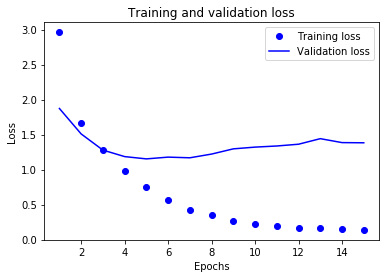

```python
# Plot of the validation and training loss

# "bo" is for "blue dot"
plt.plot(epochs, loss, 'bo', label='Training loss')
# b is for "solid blue line"
plt.plot(epochs, val_loss, 'b', label='Validation loss')
plt.title('Training and validation loss')
plt.xlabel('Epochs')
plt.ylabel('Loss')
plt.legend()

plt.show()
```

## Predicting Student Admissions

Predict student admissions based on three pieces of data:

- GRE Scores
- GPA Scores
- Class rank

### Load and visualize the data

```python
student_data = pd.read_csv("student_data.csv")
print(student_data)
```

```
     admit  gre   gpa  rank
0        0  380  3.61     3
1        1  660  3.67     3
2        1  800  4.00     1
3        1  640  3.19     4
4        0  520  2.93     4
5        1  760  3.00     2
6        1  560  2.98     1
7        0  400  3.08     2
8        1  540  3.39     3
9        0  700  3.92     2
10       0  800  4.00     4
11       0  440  3.22     1
12       1  760  4.00     1
13       0  700  3.08     2
```

[output cut: 49 more lines]

Plot of the GRE and the GPA from the data.

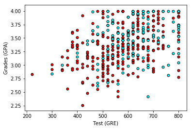

```python
X = np.array(student_data[["gre","gpa"]])
y = np.array(student_data["admit"])
admitted = X[np.argwhere(y==1)]
rejected = X[np.argwhere(y==0)]
plt.scatter([s[0][0] for s in rejected], [s[0][1] for s in rejected], s = 25, color = 'red', edgecolor = 'k')
plt.scatter([s[0][0] for s in admitted], [s[0][1] for s in admitted], s = 25, color = 'cyan', edgecolor = 'k')
plt.xlabel('Test (GRE)')
plt.ylabel('Grades (GPA)')

plt.show()
```

Plot of the data by class rank.

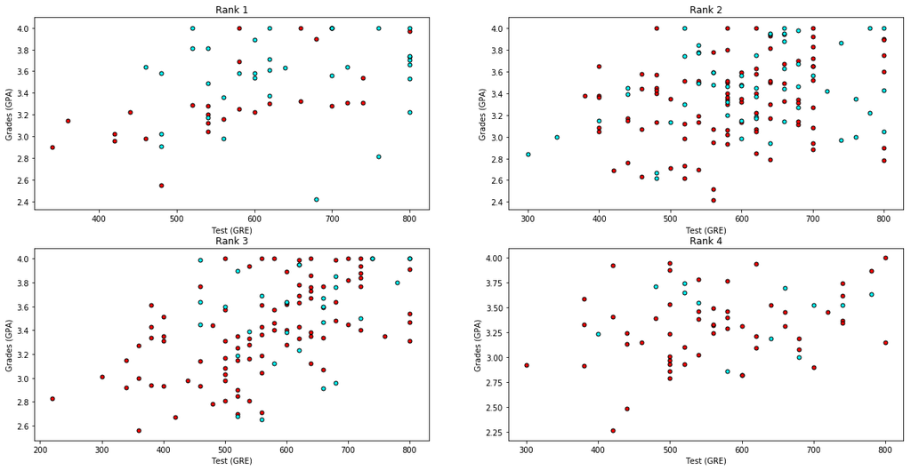

```python
f, plots = plt.subplots(2, 2, figsize=(20,10))
plots = [plot for sublist in plots for plot in sublist]

for idx, plot in enumerate(plots):
    data_rank = student_data[student_data["rank"]==idx+1]
    plot.set_title("Rank " + str(idx+1))
    X = np.array(data_rank[["gre","gpa"]])
    y = np.array(data_rank["admit"])
    admitted = X[np.argwhere(y==1)]
    rejected = X[np.argwhere(y==0)]
    plot.scatter([s[0][0] for s in rejected], [s[0][1] for s in rejected], s = 25, color = 'red', edgecolor = 'k')
    plot.scatter([s[0][0] for s in admitted], [s[0][1] for s in admitted], s = 25, color = 'cyan', edgecolor = 'k')
    plot.set_xlabel('Test (GRE)')
    plot.set_ylabel('Grades (GPA)')
```

#### TO DO: Preprocess the data

1. Normalize the input data set
2. Perform one hot encoding
3. Create a train, test, and validation set

```python
mean_gre = student_data["gre"].mean()
std_gre = student_data["gre"].std()

mean_gpa = student_data["gpa"].mean()
std_gpa = student_data["gpa"].std()


student_data['gpa'] -= mean_gpa
student_data['gpa'] /= std_gpa

student_data['gre'] -= mean_gre
student_data['gre'] /= std_gre

data = np.zeros((student_data.shape[0],6))

rank = np.array(student_data[["rank"]])
rank = to_categorical(rank-1)

data[:,0] = np.array(student_data["gre"])
data[:,1] = np.array(student_data["gpa"])
data[:,2:6] = rank

labels = np.array(student_data["admit"])

train_data = data[:300]
train_labels = to_categorical(labels[:300])

test_data = data[300:]
test_labels = to_categorical(labels[300:])

print (train_data.shape)
print (train_labels.shape)
print (test_data.shape)
print (test_labels.shape)
```

```
(300, 6)
(300, 2)
(97, 6)
(97, 2)
```

1. Use a validation set
2. Propose and train a network
3. Print the history of the training
4. Evaluate with a test set

```python
network = models.Sequential()

network.add(layers.Dense(128, activation='relu', input_dim=6))
network.add(layers.Dropout(0.1))
network.add(layers.Dense(16, activation='relu'))
network.add(layers.Dropout(0.1))
network.add(layers.Dense(2, activation='softmax'))
network.summary()

# included the early stopping which monitors the validation loss
network.compile(loss='binary_crossentropy',
              optimizer='rmsprop',
              metrics=['accuracy'])


# Early Stop
early_stop = callbacks.EarlyStopping(monitor='val_loss', patience=10)
```

```
_________________________________________________________________
Layer (type)                 Output Shape              Param #
=================================================================
dense_12 (Dense)             (None, 128)               896
_________________________________________________________________
dropout_10 (Dropout)         (None, 128)               0
_________________________________________________________________
dense_13 (Dense)             (None, 16)                2064
_________________________________________________________________
dropout_11 (Dropout)         (None, 16)                0
_________________________________________________________________
dense_14 (Dense)             (None, 2)                 34
=================================================================
Total params: 2,994
Trainable params: 2,994
Non-trainable params: 0
_________________________________________________________________
```

```python
history = network.fit(train_data, train_labels,
          batch_size=512,
          epochs=200,
          validation_split=0.1,
          callbacks=[early_stop],
          verbose=2)
```

```
Train on 270 samples, validate on 30 samples
 - 1s - loss: 0.6799 - acc: 0.5741 - val_loss: 0.6421 - val_acc: 0.7000
 - 0s - loss: 0.6368 - acc: 0.6778 - val_loss: 0.6337 - val_acc: 0.6667
 - 0s - loss: 0.6210 - acc: 0.6926 - val_loss: 0.6283 - val_acc: 0.6667
 - 0s - loss: 0.6077 - acc: 0.7000 - val_loss: 0.6261 - val_acc: 0.6667
 - 0s - loss: 0.6029 - acc: 0.6852 - val_loss: 0.6242 - val_acc: 0.6667
 - 0s - loss: 0.5965 - acc: 0.7037 - val_loss: 0.6248 - val_acc: 0.6333
 - 0s - loss: 0.5798 - acc: 0.7333 - val_loss: 0.6231 - val_acc: 0.6667
 - 0s - loss: 0.5814 - acc: 0.7111 - val_loss: 0.6242 - val_acc: 0.6667
 - 0s - loss: 0.5688 - acc: 0.7222 - val_loss: 0.6258 - val_acc: 0.6667
 - 0s - loss: 0.5700 - acc: 0.7333 - val_loss: 0.6260 - val_acc: 0.6667
 - 0s - loss: 0.5649 - acc: 0.7444 - val_loss: 0.6274 - val_acc: 0.6667
 - 0s - loss: 0.5693 - acc: 0.7296 - val_loss: 0.6283 - val_acc: 0.6667
 - 0s - loss: 0.5546 - acc: 0.7481 - val_loss: 0.6299 - val_acc: 0.6667
 - 0s - loss: 0.5535 - acc: 0.7519 - val_loss: 0.6317 - val_acc: 0.6667
 - 0s - loss: 0.5589 - acc: 0.7333 - val_loss: 0.6334 - val_acc: 0.7000
 - 0s - loss: 0.5610 - acc: 0.7333 - val_loss: 0.6348 - val_acc: 0.7000
 - 0s - loss: 0.5489 - acc: 0.7370 - val_loss: 0.6346 - val_acc: 0.7000
```

```python
test_loss, test_acc = network.evaluate(test_data, test_labels)
print("test loss: ", test_loss, "test accuracy: ", test_acc)
```

```
test loss:  0.6644864269753092 test accuracy:  0.6288659793814433
```

```python
# This dictionary stores the validation and accuracy of the model throughout the epochs
history_dict = history.history
print(history_dict.keys())
```

```
dict_keys(['val_loss', 'val_acc', 'loss', 'acc'])
```

```python
# The history values are split in different lists for ease of plotting
acc = history_dict['acc']
val_acc = history_dict['val_acc']
loss = history_dict['loss']
val_loss = history_dict['val_loss']

epochs = range(1, len(acc) + 1)
```

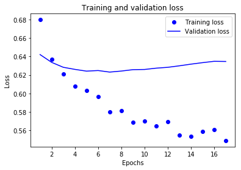

```python
# Plot of the validation and training loss

# "bo" is for "blue dot"
plt.plot(epochs, loss, 'bo', label='Training loss')
# b is for "solid blue line"
plt.plot(epochs, val_loss, 'b', label='Validation loss')
plt.title('Training and validation loss')
plt.xlabel('Epochs')
plt.ylabel('Loss')
plt.legend()

plt.show()
```